# Remuestreo

2022-11-05

## Bootstrapping para 2 Muestras Independientes

### Se fija una semilla

```r
set.seed(2349)
```

### Creación del dataset de acuerdo a los datos entregados

```r
materna <- c(87.9, 92.5, 88.1, 89.9, 87.8, 92.6, 88.0, 91.2, 86.8, 87.0, 88.0,
             91.3, 89.2, 88.2)
formula <- c(91.7, 87.9, 87.6, 88.1, 89.2, 87.4, 93.8, 89.1, 88.4, 89.4, 91.8,
             87.0, 87.7, 89.5, 87.9, 88.2)
n_materna <- length(materna)
n_formula <- length(formula)
leche <- c(rep("Materna", n_materna), rep("Fórmula", n_formula))
estatura <- c(materna, formula)
datos <- data.frame(estatura, leche)
summary(datos)
```

```
##     estatura        leche
##  Min.   :86.80   Length:30
##  1st Qu.:87.90   Class :character
##  Median :88.20   Mode  :character
##  Mean   :89.11
##  3rd Qu.:89.80
##  Max.   :93.80
```

## Hipótesis

- $H_0$: No existe diferencia en la estatura promedio entre los niños varones de dos años que se alimentan con leche materna con los que se alimentan con leche de fórmula.
- $H_A$: Existe diferencia en la estatura promedio entre los niños varones de dos años que se alimentan con leche materna con los que se alimentan conleche de fórmula.

### Hipótesis Matemática

- Sea μm la media de la estatura de los niños de dos años que se alimentan de leche materna y μf la media de la estatura de los niños de dos años que se alimentan de leche de fórmula:
- $H_0$ μm – μf = 0
- $H_A$ μm – μf != 0

### Comprobar normalidad de las muestras

```r
alfa <- 0.05
shapiro.test(materna)
```

```
##
##  Shapiro-Wilk normality test
##
## data:  materna
## W = 0.87293, p-value = 0.04613
```

```r
shapiro.test(formula)
```

```
##
##  Shapiro-Wilk normality test
##
## data:  formula
## W = 0.84105, p-value = 0.01009
```

### Calcular la diferencia observada entre las medias muestrales

```r
media_materna <- mean(materna)
media_formula <- mean(formula)
valor_nulo <- 0
valor_observado <- media_materna - media_formula # Valor observado o diferencia
cat("Diferencia Observada:",valor_observado)
```

```
## Diferencia Observada: 0.1348214
```

### Creación Distribución Bootstrap

```r
B <- 9999
alfa <- 0.05
distribucion_bootstrap <- two.boot(materna, formula, FUN = mean, R = B)
valores <- data.frame(distribucion_bootstrap$t)
colnames(valores) <- "valores"
```

### Histograma

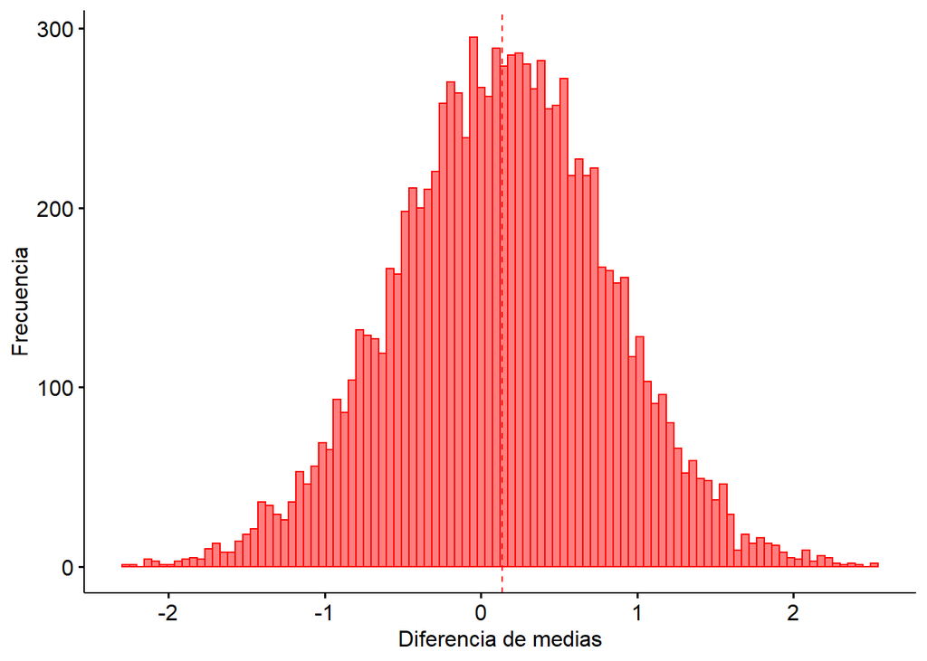

```r
histograma <- gghistogram(valores, x = "valores", color = "red",
                          fill = "red", bins = 100,
                          xlab = "Diferencia de medias",
                          ylab = "Frecuencia", add = "mean")
print(histograma)
```

### Gráfico Q-Q

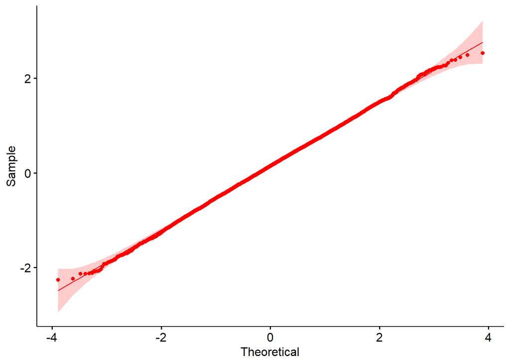

```r
qq <- ggqqplot(valores, x = "valores", color = "red")
print(qq)
```

Del histograma es posible observar como la forma de los datos describe una distribución normal, además el grafico Q-Q no muestra ningún dato atípico, es por esto que es posible afirmar que los datos remuestreados ahora si cumplen con el supuesto de normalidad.

### Media y desviación de la distribución bootstrap generada

```r
cat("Distribución bootstrap:\n")
```

```
## Distribución bootstrap:
```

```r
cat("\tMedia:", mean(valores$valores), "\n")
```

```
##  Media: 0.1354755
```

```r
cat("\tDesviación estándar:", sd(valores$valores), "\n\n")
```

```
##  Desviación estándar: 0.681072
```

### Construcción del intervalo de confianza.

```r
intervalo_bca <- boot.ci(distribucion_bootstrap, conf = 1 - alfa,                         type = "bca")
print(intervalo_bca)
```

```
## BOOTSTRAP CONFIDENCE INTERVAL CALCULATIONS
## Based on 9999 bootstrap replicates
##
## CALL :
## boot.ci(boot.out = distribucion_bootstrap, conf = 1 - alfa, type = "bca")
##
## Intervals :
## Level       BCa
## 95%   (-1.2357,  1.4616 )
## Calculations and Intervals on Original Scale
```

### Cálculo de la prueba de hipótesis

```r
desplazamiento <- mean(distribucion_bootstrap[["t"]]) - valor_nulo
distribucion_nula <- distribucion_bootstrap[["t"]] - desplazamiento
```

### Se calcula el p-value

```r
p <- (sum(abs(distribucion_nula) > abs(valor_observado)) + 1) / (B + 1)
cat("p-value:", p)
```

```
## p-value: 0.8445
```

## Conclusión

La diferencia entre las medias tiene un valor de 0.1354 y se encuentra dentro del intervalo de confianza [-1.2357, 1.4616], además tomando en consideración el valor p obtenido igual a 0.8445, resultado bastante mayor al nivel de significación alfa = 0.05 por lo que se falla en rechazar la hipótesis nula. En conclusión, es posible afirmar con 95% de confianza que no existe diferencia en las estaturas promedio entre los niños varones de dos años que se alimentan con leche materna con los que se alimentan con leche de fórmula.

## Bootstrapping para 2 Muestras Pareadas

Se desea saber si existe diferencia entre las calificaciones obtenidas en la primera y la segunda prueba ### Datos

```r
set.seed (432)
alumno <- 1:20
prueba_1 <- c(3.5 , 2.7 , 1.0 , 1.8 , 1.6 , 4.3 , 5.8 , 6.4 , 3.9 , 4.3 , 3.4 ,5.3 , 5.8 , 5.3 , 2.0 , 1.3 , 4.0 , 5.3 , 1.6, 3.6)
prueba_2 <- c(5.2 , 5.1 , 5.9 , 4.8 , 1.4 , 2.3 , 6.8 , 5.3 , 3.1 , 3.8 , 4.6 ,1.2 , 3.9 , 2.0 , 1.7 , 3.3 , 6.0 , 4.8 , 6.9 , 1.3)
data.frame(alumno, prueba_1, prueba_2)
```

```
##    alumno prueba_1 prueba_2
## 1       1      3.5      5.2
## 2       2      2.7      5.1
## 3       3      1.0      5.9
## 4       4      1.8      4.8
## 5       5      1.6      1.4
## 6       6      4.3      2.3
## 7       7      5.8      6.8
## 8       8      6.4      5.3
## 9       9      3.9      3.1
## 10     10      4.3      3.8
## 11     11      3.4      4.6
## 12     12      5.3      1.2
## 13     13      5.8      3.9
## 14     14      5.3      2.0
## 15     15      2.0      1.7
## 16     16      1.3      3.3
## 17     17      4.0      6.0
## 18     18      5.3      4.8
## 19     19      1.6      6.9
## 20     20      3.6      1.3
```

### Remuestreo

```r
diferencia <- prueba_2 - prueba_1 # Se crea una nueva columna de diferencia
B <- 3999
valor_nulo <- 0
valor_observado <- mean ( diferencia )
distribucion_bootstrapES <- bootES( diferencia , R = B , ci.type = "bca",ci.conf = 1 - alfa , plot = FALSE )
print (distribucion_bootstrapES )
```

```
##
## 95.00% bca Confidence Interval, 3999 replicates
## Stat        CI (Low)    CI (High)   bias        SE
## 0.325       -0.656      1.439       0.001       0.541
```

```r
distribucion_nula <- distribucion_bootstrapES [["t"]] - valor_nulo
```

### p-value

```r
p <- ( sum( abs( distribucion_nula ) > abs( valor_observado ) ) + 1) / ( B + 1)
cat (" Valor p:", p )
```

```
##  Valor p: 0.60575
```

### Conclusión

A partir del resultado anterior, concluimos con 95 % de confianza que, en promedio, la diferencia de las medias para las calificaciones de la primera y la segunda evaluación se encuentra en el intervalo (−0, 656; 1, 439), por lo que no podemos desechar la idea de que no existe una diferencia estadísticamente significativa entre ellas

### Con distinto valor nulo (0.5)

Ahora la Universidad del ejemplo desea saber si la diferencia promedio entre las calificaciones obtenidas en la primera y la segunda prueba de un curso inicial de programación es de 5 décimas. Así, considerando un nivel de significación α = 0, 05, los investigadores formulan las siguientes hipótesis:

Sea µdif la media de las diferencias en las calificaciones obtenidas por los estudiantes en la primera y la segunda prueba del curso inicial de programación de la Universidad, entonces: H0: µdif = 0,5 H0: µdif ̸= 0,5

```r
valor_nulo <- 0.5
distribucion_nula <- distribucion_bootstrapES [["t"]] - valor_nulo
```

### p-value

```r
p <- ( sum( abs( distribucion_nula ) > abs( valor_observado ) ) + 1) / ( B + 1)
cat (" Valor p:", p )
```

```
##  Valor p: 0.5725
```